# 『問題解決力を鍛える！ アルゴリズムとデータ構造』

挿入対象と入れ替え対象の頂点の描画用のデータフレームを作成します。

```r
# 試行番号を取得
step_vec <- unique(trace_df[["step"]])

# 入替対象の頂点の座標を作成
target_vertex_df <- trace_vertex_df |>
  dplyr::filter(target_flag) |> # 挿入・入替対象を抽出
  dplyr::mutate(
    frame_id = dplyr::dense_rank(step), # 試行回数の抽出用
    step     = step_vec[frame_id] # 表示フレームを調整
  ) |>
  dplyr::arrange(step, index)
target_vertex_df |>
  dplyr::select(!c(col_idx, coord_x)) # (資料作成用に間引き)
```

```
## # A tibble: 108 × 8
##     step    id index value target_flag insert_flag depth frame_id
##    <dbl> <int> <dbl> <int> <lgl>       <lgl>       <dbl>    <int>
##  1   0       2     2     2 TRUE        TRUE            1        1
##  2   0.5     1     1    15 TRUE        TRUE            0        2
##  3   0.5     2     2     2 TRUE        TRUE            1        2
##  4   1       3     3    12 TRUE        TRUE            1        3
##  5   1.5     1     1    15 TRUE        TRUE            0        4
##  6   1.5     3     3    12 TRUE        TRUE            1        4
##  7   2       4     4    25 TRUE        TRUE            2        5
##  8   2.5     4     2    25 TRUE        TRUE            1        6
##  9   2.5     2     4     2 TRUE        TRUE            2        6
## 10   3       4     1    25 TRUE        TRUE            0        7
## # ℹ 98 more rows
```

各試行の頂点の座標データ `trace_vertex_df` から、各試行における挿入対象または入れ替え対象の要素の座標データ(`target_flag` 列が `TRUE` の行)を取り出します。  
1試行早く表示するために、`step` 列の値を1つ前の値に置き換えます。（挿入時は試行番号を0.5刻みでカウントしているので-1では意図通りに描画されません。）

入れ替え対象の頂点を結ぶ辺の描画用のデータフレームを作成します。

```r
# 入替対象の辺の座標を作成
target_edge_df <- trace_vertex_df |>
  dplyr::filter(target_flag) |> # 挿入・入替対象を抽出
  dplyr::mutate(
    frame_id = dplyr::dense_rank(step), # 試行回数の抽出用
  ) |>
  dplyr::filter(step%%1 == 0) |> # 入替対象を抽出(挿入対象を除去)
  dplyr::group_by(step) |> # 辺IDの作成用
  dplyr::mutate(
    edge_label = paste0("step: ", step, ", id: ", min(index)) # 線分間の干渉回避用
  ) |>
  dplyr::ungroup() |>
  dplyr::mutate(
    step = step_vec[frame_id] # 表示フレームを調整
  ) |>
  dplyr::arrange(step, index)
target_edge_df |>
  dplyr::select(!c(col_idx, coord_x)) # (資料作成用に間引き)
```

```
## # A tibble: 84 × 9
##     step    id index value target_flag insert_flag depth frame_id edge_label
##    <dbl> <int> <dbl> <int> <lgl>       <lgl>       <dbl>    <int> <chr>
##  1   0.5     1     1    15 TRUE        TRUE            0        2 step: 1, id: 1
##  2   0.5     2     2     2 TRUE        TRUE            1        2 step: 1, id: 1
##  3   1.5     1     1    15 TRUE        TRUE            0        4 step: 2, id: 1
##  4   1.5     3     3    12 TRUE        TRUE            1        4 step: 2, id: 1
##  5   2.5     4     2    25 TRUE        TRUE            1        6 step: 3, id: 2
##  6   2.5     2     4     2 TRUE        TRUE            2        6 step: 3, id: 2
##  7   3       4     1    25 TRUE        TRUE            0        7 step: 4, id: 1
##  8   3       1     2    15 TRUE        TRUE            1        7 step: 4, id: 1
##  9   4.5     1     2    15 TRUE        TRUE            1        9 step: 5, id: 2
## 10   4.5     5     5    14 TRUE        TRUE            2        9 step: 5, id: 2
## # ℹ 74 more rows
```

試行ID(試行回数に対する通し番号)を割り当ててから、挿入時のデータ(`step` 列が小数点以下の値を持つ行)を取り除いて、試行回数(フレーム用の値)を1つ前の値に置き換えます。

値の挿入とヒープ化の推移のアニメーションを作成します。

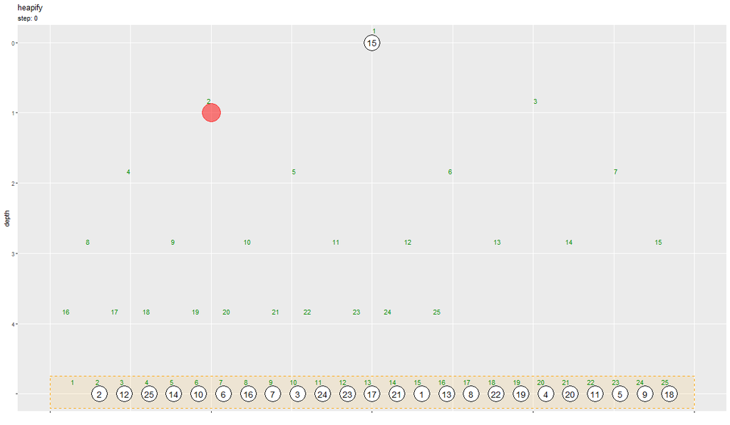

```r
# ヒープ化のアニメーションを作図
graph <- ggplot() +
  geom_rect(mapping = aes(xmin = 0, xmax = 1, ymin = max_y-0.25, ymax = max_y+0.2),
            fill = "orange", color = "orange", alpha = 0.1, linetype ="dashed") + # 数列枠
  geom_path(data = trace_edge_df,
            mapping = aes(x = coord_x, y = depth, group = edge_label),
            linewidth = 1) + # 辺
  geom_path(data = target_edge_df,
            mapping = aes(x = coord_x, y = depth, group = edge_label),
            color = "red", linewidth = 1, linetype = "dashed") + # 入替対象の辺
  geom_point(data = target_vertex_df,
             mapping = aes(x = coord_x, y = depth, group = step),
             size = 14, color = "red", alpha = 0.5) + # 挿入・入替対象の頂点
  geom_point(data = trace_vertex_df,
             mapping = aes(x = coord_x, y = depth, group = id),
             size = 12, shape = "circle filled", fill = "white", stroke = 1) + # 頂点
  geom_text(data = trace_vertex_df,
            mapping = aes(x = coord_x, y = depth, label = as.character(value), group = id),
            size = 5) + # 値ラベル
  geom_text(data = index_df,
            mapping = aes(x = coord_x, y = depth, label = index, hjust = offset),
            size = 4, vjust = -1.7, color = "green4") + # インデックスラベル:(ツリー用)
  geom_text(data = index_df,
            mapping = aes(x = index/(N+1), y = max_y, label = index),
            size = 4, hjust = 1.1, vjust = -1.7, color = "green4") + # インデックスラベル:(数列用)
  gganimate::transition_states(states = step, transition_length = 9, state_length = 1, wrap = FALSE) + # フレーム遷移
  gganimate::ease_aes("cubic-in-out") + # 遷移の緩急
  scale_x_continuous(labels = NULL) +
  scale_y_reverse(breaks = 0:max_y, labels = c(as.character(0:(max_y-1)), ""), minor_breaks = FALSE) +
  coord_cartesian(xlim = c(0, 1), ylim = c(max_y, 0)) +
  labs(title = "heapify",
       subtitle = "step: {next_state}",
       x = "", y = "depth")

# フレーム数を取得
frame_num <- trace_df[["step"]] |>
  unique() |>
  length()

# 遷移フレーム数を指定
s <- 20

# gif画像を作成
gganimate::animate(
  plot = graph,
  nframes = (frame_num + 2)*s, start_pause = s, end_pause = s, fps = 20,
  width = 1200, height = 700,
  renderer = gganimate::gifski_renderer()
)
```

挿入対象または入替対象の頂点を赤色の丸、未挿入の要素をオレンジ色の枠の塗りつぶしで示します。

数列の要素を1つずつヒープの末尾に挿入して、それぞれヒープ条件を満たすまで挿入値とその親を入れ替えていくことで、数列全体がヒープ化されるのを確認できます。  
数列全体をヒープとして用いた場合と比べて、ヒープ用のオブジェクト(メモリ)が必要で、操作の回数が増えるのを確認できます。

## 最大値の削除

最後は、ヒープの最大値を削除する操作の実装と可視化を行います。

### 最大値の削除の実装

二分ヒープの最大値の削除のアルゴリズムを関数として実装します。

最大値の削除を実装します。

```r
# 最大値の削除の実装
pop <- function(vec) {

  # 削除後の要素数を取得
  N <- length(vec) - 1

  # 末尾(挿入要素)の値を取得
  val <- vec[N+1]

  # 末尾の値を削除
  vec <- vec[-(N+1)]

  # 根(親)のインデックスを設定
  i <- 1

  # ヒープ化
  while(i*2 <= N) { # (葉に達するまで)

    # 左側の子のインデックスを計算
    child_idx <- i * 2

    # 値が大きい方の子のインデックスを設定
    if(child_idx+1 <= N & vec[child_idx+1] > vec[child_idx]) { # (&の左がFALSEだと右が処理されずNAにならない)
      child_idx <- child_idx + 1
    }

    # 子が親以下なら終了
    if(vec[child_idx] <= val) break

    # 親と子を入替
    vec[i] <- vec[child_idx] # 子の値を親の位置に移動
    i      <- child_idx      # 挿入位置を子の位置に更新
  }

  # 値を挿入
  vec[i] <- val

  # 数列を出力
  return(vec)
}
```

ヒープ化済みの数列を `vec`、削除後の要素数を `N`、挿入する値(末尾の値)を `val`、値の挿入位置(インデックス)を `i` とします。  
`vec` の(先頭ではなく)末尾の要素を削除して、`i` の初期値として先頭(最大値)のインデックスを設定します。この操作が、最大値の削除と、末尾の要素の先頭への挿入に対応します。  
`i` 番目の頂点(要素)の2つの子の内、値が大きい方のインデックスを `childe_idx` として計算します。頂点 $v_i$ の子 $v_j, v_{j+1}$ のインデックスは $j = 2 i$ で求まります。

挿入する値 `val` と子の値 `vec[child_idx]` を大小比較していき、挿入位置 `i` を探索します。  
挿入する値が小さければ、`vec` の `child_idx` 番目の値を `i` 番目に複製し、挿入位置 `i` を `child_idx` に更新します。この操作が、親子要素の入れ替えに対応します。ただしこの時点では、`vec` の `i, child_idx` 番目が同じ値です。  
「子の値が挿入値以下」または「挿入位置が葉(子がない)」であれば、ループ処理を終了して、`vec` の `i` 番目に `val` を代入します。この操作によって入れ替えが完了します。

アルゴリズムの詳しい解説は、本のcode 10.5(後半)などを参照してください。

実装した関数を試してみます。

ヒープを作成して、最大値を削除します。

```r
# 要素数を指定
N <- 25

# (簡易的に)数列を作成
a <- 1:N

# ヒープ化
a <- heapify(a)

# 最大値を削除してヒープ化
a <- pop(a)
a; length(a)
```

```
##  [1] 24 23 15 19 22 13 14 17 18 21 11 12  1  3  7 16  8  4  9 20 10  5  2  6
```

```
## [1] 24
```

要素数が1つ減ります。

「ヒープの可視化」のときのコードで、最大値を削除したヒープをバイナリツリーで確認します。

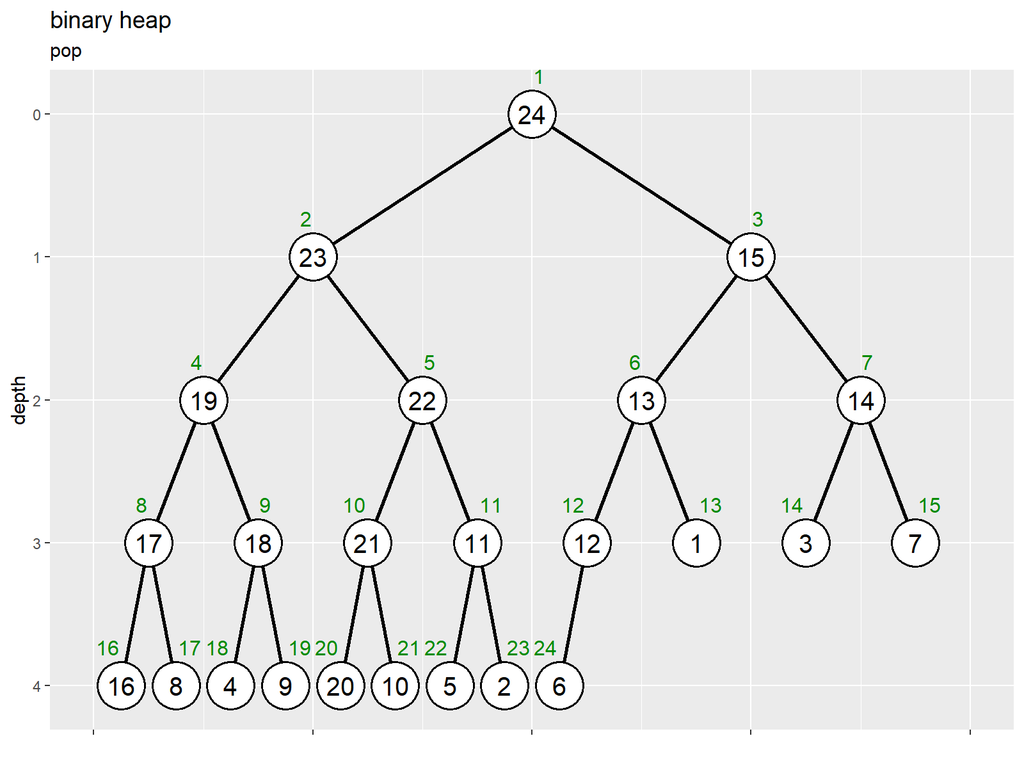

「ヒープの可視化」のときの図から、この図に変化します。

### 最大値の削除の可視化

続いて、二分ヒープの最大値の削除のアルゴリズムをグラフで確認します。

アルゴリズムに従いヒープ化を行って、作図用のデータを作成します。

要素数を指定して、ヒープを作成します。

```r
# 要素数を指定
initial_N <- 20

# ヒープを作成
initial_a <- sample(x = 1:initial_N, size = initial_N, replace = FALSE) |>
  heapify()
initial_a
```

```
##  [1] 20 19 18 16 17 12 14 15 11  7 10  4  6  1  3  9 13  8  2  5
```

`N + 1` 個の値を作成して、`heapify()` でヒープ化します。

最大値を削除します。

```r
# 最大値を削除して、末尾を先頭に挿入
a <- c(initial_a[initial_N], initial_a[-c(1, initial_N)])

# 削除後の要素数を取得
N <- length(a)
a; N
```

```
##  [1]  5 19 18 16 17 12 14 15 11  7 10  4  6  1  3  9 13  8  2
```

```
## [1] 19
```

ヒープ(数列)の先頭(最大値)の要素を削除して、末尾の要素を先頭に挿入します。

数列の記録用のデータフレームを作成します。

```r
# 数列を格納
trace_df <- dplyr::bind_rows(
  # 初期値
  tibble::tibble(
    step  = 0,
    id    = 1:initial_N,
    index = id,
    value = initial_a,
    target_flag = FALSE,
    heap_flag   = TRUE
  ),
  # 削除後
  tibble::tibble(
    step  = 1,
    id    = c(initial_N, 2:N, 1),
    index = 1:initial_N,
    value = c(a, NA),
    target_flag = index %in% c(1, initial_N), # 挿入・削除対象
    heap_flag   = c(rep(TRUE, times = N), FALSE) # ヒープ要素
  )
)
trace_df
```

```
## # A tibble: 40 × 6
##     step    id index value target_flag heap_flag
##    <dbl> <dbl> <int> <int> <lgl>       <lgl>
##  1     0     1     1    20 FALSE       TRUE
##  2     0     2     2    19 FALSE       TRUE
##  3     0     3     3    18 FALSE       TRUE
##  4     0     4     4    16 FALSE       TRUE
##  5     0     5     5    17 FALSE       TRUE
##  6     0     6     6    12 FALSE       TRUE
##  7     0     7     7    14 FALSE       TRUE
##  8     0     8     8    15 FALSE       TRUE
##  9     0     9     9    11 FALSE       TRUE
## 10     0    10    10     7 FALSE       TRUE
## # ℹ 30 more rows
```

初期値(削除前)と削除後の数列をデータフレームに格納します。ただし削除要素の作図用に、削除後の最大値に対応する値(行)を含めておきます。以降の処理では含めません。

1試行ずつ入れ替え処理を行い、数列を記録します。

```r
# 挿入要素のインデックスを設定
i <- 1

# 作図用のオブジェクトを初期化
id_vec <- c(initial_N, 2:N)

# ヒープ化
iter <- 1
break_flag <- FALSE
while(i*2 <= N) {

  # 試行回数を更新
  iter <- iter + 1

  # 値が大きい方の子のインデックスを設定
  child_idx <- i * 2 # 左側の子
  if(child_idx+1 <= N & a[child_idx+1] > a[child_idx]) {
    child_idx <- child_idx + 1
  }

  # 子が親より大きいなら入替
  if(a[child_idx] > a[i]) {
    a[1:N]      <- replace(x = a, list = c(i, child_idx), values = a[c(child_idx, i)])
    id_vec[1:N] <- replace(x = id_vec, list = c(i, child_idx), values = id_vec[c(child_idx, i)])
  } else {
    break_flag <- TRUE
  }

  # 数列を格納
  tmp_df <- tibble::tibble(
    step  = iter,
    id    = id_vec,
    index = 1:N,
    value = a,
    target_flag = index %in% c(i, i*2, i*2+1), # 入替対象
    heap_flag   = TRUE
  )

  # 数列を記録
  trace_df <- dplyr::bind_rows(trace_df, tmp_df)

  # 挿入位置を子の位置に更新
  i <- child_idx

  # 途中経過を表示
  #print(paste0("--- step: ", iter, " ---"))
  #print(a)
}
```

「最大値を削除の実装」のときと同様にして要素を入れ替えていき、試行ごとに数列やインデックスをデータフレームに保存します。

各試行の二分木のグラフを切り替えて推移を確認します。

試行ごとの頂点の描画用のデータフレームを作成します。

```r
# 全ての頂点の座標を作成
tmp_vertex_df <- trace_df |>
  dplyr::mutate(
    depth   = floor(log2(index)), # 縦方向の頂点位置
    col_idx = index - 2^depth + 1, # 深さごとの頂点番号
    coord_x = (col_idx * 2 - 1) * 1/(2^depth * 2), # 横方向の頂点位置
  )

# ヒープの頂点の座標を作成
trace_vertex_df <- tmp_vertex_df |>
  dplyr::filter(heap_flag) # ヒープ要素を抽出(最大値を除去)
trace_vertex_df
```

```
## # A tibble: 96 × 9
##     step    id index value target_flag heap_flag depth col_idx coord_x
##    <dbl> <dbl> <int> <int> <lgl>       <lgl>     <dbl>   <dbl>   <dbl>
##  1     0     1     1    20 FALSE       TRUE          0       1  0.5
##  2     0     2     2    19 FALSE       TRUE          1       1  0.25
##  3     0     3     3    18 FALSE       TRUE          1       2  0.75
##  4     0     4     4    16 FALSE       TRUE          2       1  0.125
##  5     0     5     5    17 FALSE       TRUE          2       2  0.375
##  6     0     6     6    12 FALSE       TRUE          2       3  0.625
##  7     0     7     7    14 FALSE       TRUE          2       4  0.875
##  8     0     8     8    15 FALSE       TRUE          3       1  0.0625
##  9     0     9     9    11 FALSE       TRUE          3       2  0.188
## 10     0    10    10     7 FALSE       TRUE          3       3  0.312
## # ℹ 86 more rows
```

「ヒープ化の可視化」のときのコードで作成したデータフレームを `tmp_vertex_df` としておきます。  
`tmp_vertex_df` から最大値(`heap_flag` が `FALSE` の行)を取り除いたデータフレームを `trace_vertex_df` とします。

「ヒープ化の可視化」のときのコードで、辺、インデックラベルの描画用のデータフレーム(`edge_df`・`index_df`)を作成します。

入れ替え対象の頂点と辺の描画用のデータフレームを作成します。

```r
# 入替対象の頂点の座標を作成
target_vertex_df <- tmp_vertex_df |>
  dplyr::filter(target_flag) |> # 入替対象の親を抽出
  dplyr::mutate(
    step = step - 1 # 表示フレームを調整
  ) |>
  dplyr::arrange(step, index)

# 入替対象の辺の座標を作成
target_edge_df <- dplyr::bind_rows(
  # 親の座標
  target_vertex_df |>
    dplyr::group_by(step) |>
    dplyr::filter(index == min(index)) |> # 親を抽出
    dplyr::ungroup() |>
    dplyr::mutate(
      n = dplyr::if_else(
        condition = step == 0, true = 1, false = 2
      )
    ) |>
    tidyr::uncount(weights = n, .id = "childe_id") |> # 子の数に複製
    dplyr::mutate(
      childe_id = childe_id - 1, # 行番号を子IDに変換
      edge_id   = dplyr::if_else(
        condition = step == 0, true = initial_N, false = index * 2 + childe_id # 子インデックス
      )
    ) |>
    dplyr::filter(edge_id <= initial_N), # 子がなければ除去
  # 子の座標
  target_vertex_df |>
    dplyr::group_by(step) |>
    dplyr::filter(index != min(index)) |> # 子を抽出
    dplyr::ungroup() |>
    dplyr::mutate(
      edge_id = index
    )
) |>
  dplyr::arrange(step, index)
target_edge_df |>
  dplyr::select(!col_idx) # (資料作成用に間引き)
```

```
## # A tibble: 14 × 10
##     step    id index value target_flag heap_flag depth coord_x childe_id edge_id
##    <dbl> <dbl> <int> <int> <lgl>       <lgl>     <dbl>   <dbl>     <dbl>   <dbl>
##  1     0    20     1     5 TRUE        TRUE          0   0.5           0      20
##  2     0     1    20    NA TRUE        FALSE         4   0.281        NA      20
##  3     1     2     1    19 TRUE        TRUE          0   0.5           0       2
##  4     1     2     1    19 TRUE        TRUE          0   0.5           1       3
##  5     1    20     2     5 TRUE        TRUE          1   0.25         NA       2
##  6     1     3     3    18 TRUE        TRUE          1   0.75         NA       3
##  7     2     5     2    17 TRUE        TRUE          1   0.25          0       4
##  8     2     5     2    17 TRUE        TRUE          1   0.25          1       5
##  9     2     4     4    16 TRUE        TRUE          2   0.125        NA       4
## 10     2    20     5     5 TRUE        TRUE          2   0.375        NA       5
## 11     3    11     5    10 TRUE        TRUE          2   0.375         0      10
## 12     3    11     5    10 TRUE        TRUE          2   0.375         1      11
## 13     3    10    10     7 TRUE        TRUE          3   0.312        NA      10
## 14     3    20    11     5 TRUE        TRUE          3   0.438        NA      11
```

ヒープの最大値を削除した際の推移のアニメーションを作成します。

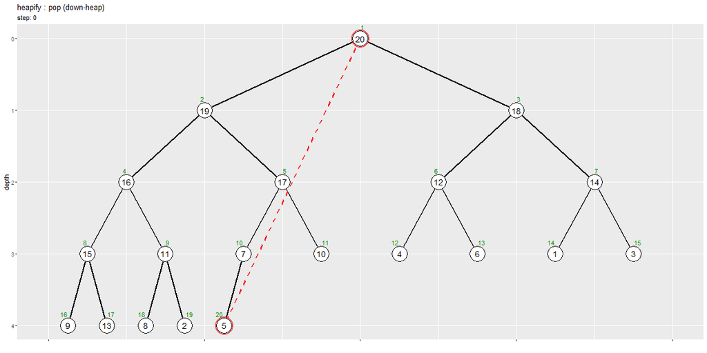

```r
# ヒープ化のアニメーションを作図
max_h <- floor(log2(N))
graph <- ggplot() +
  geom_path(data = edge_df,
            mapping = aes(x = coord_x, y = depth, group = edge_id),
            linewidth = 1) + # 辺
  geom_path(data = target_edge_df,
            mapping = aes(x = coord_x, y = depth, group = edge_id),
            color = "red", linewidth = 1, linetype = "dashed") + # 入替対象の辺
  geom_point(data = target_vertex_df,
             mapping = aes(x = coord_x, y = depth, group = step),
             size = 14, color = "red", alpha = 0.5) + # 入替対象の頂点
  geom_point(data = trace_vertex_df,
             mapping = aes(x = coord_x, y = depth, group = id),
             size = 12, shape = "circle filled", fill = "white", stroke = 1) + # 頂点
  geom_text(data = trace_vertex_df,
            mapping = aes(x = coord_x, y = depth, label = as.character(value), group = id),
            size = 5) + # 値ラベル
  geom_text(data = index_df,
            mapping = aes(x = coord_x, y = depth, label = index, hjust = offset),
            size = 4, vjust = -1.7, color = "green4") + # インデックスラベル
  gganimate::transition_states(states = step, transition_length = 9, state_length = 1, wrap = FALSE) + # フレーム遷移
  gganimate::ease_aes("cubic-in-out") + # 遷移の緩急
  scale_x_continuous(labels = NULL) +
  scale_y_reverse(breaks = 0:max_h, minor_breaks = FALSE) +
  coord_cartesian(xlim = c(0, 1)) +
  labs(title = "heapify : pop (down-heap)",
       subtitle = "step: {next_state}",
       x = "", y = "depth")

# フレーム数を取得
frame_num <- max(trace_df[["step"]]) + 1

# 遷移フレーム数を指定
s <- 20

# gif画像を作成
gganimate::animate(
  plot = graph,
  nframes = (frame_num + 2)*s, start_pause = s, end_pause = s, fps = 20,
  width = 1200, height = 600,
  renderer = gganimate::gifski_renderer()
)
```

削除対象または入替対象の頂点を赤色の塗りつぶしで示します。

ヒープ化されている元の要素数を $N$ とすると、$1$ 番目(先頭・根)の頂点(要素)を削除して代わりに $N$ 番目(末尾)の要素を挿入します。ヒープ条件を満たさなくなる場合があるので、先頭に挿入した(元末尾の)値と子の値を比較・入替を繰り返します。  
ヒープ条件を満たすまで、挿入値とその子を入れ替えていくことでヒープ化されるのを確認できます。

この記事では、ヒープ化を実装しました。次の記事では、ヒープソートを実装します。